# Basic Functionality

Christopher Marks

2019-01-18

This vignette works through the basic Twitter collection functions offered by the twinfoR package. The ‘US Politics’ vignettes demonstrate more advanced collection and analysis functionality.

# Package Import

Let’s start by importing the `twinfoR` namespace. Don’t forget to install the package, if you haven’t already.

```r
# install.packages("twinfoR.zip",repos=NULL,type="binary")
library(twinfoR)
```

# Authentication

Authenticating an App in R can be tricky, but the authentication methods supplied by this package aim to simplify the process. These functions are

- `authorize_app`
- `authorize_IT`

The documentation for these functions has more information about their usage.

We’ll use the [INFORM-Tutorial](http://zlisto.scripts.mit.edu/informs_tutorial/tutorial.html) Twitter Application (i.e., `authorize_IT`). Alternatively, you can supply your own application credentials using the `authorize_app` function.

*You will need a Twitter Account to continue!* If you don’t have one, you can easily create one on the [Twitter](https://twitter.com) website. If you do not have a Twitter account and do not wish to make one, *this package will be of very limited use to you*.

I recommend logging onto Twitter in your Browser before running the following line of code. Either way, you must be careful not to hit immediately after running it, for example by copying and pasting the whole line including a the ‘newline’ character into an R console. A good way to prevent this problem is to *manually type* the following line into the console.

```r
auth.vector <- authorize_IT()
```

This function attempts to browse to a web page that allows you to authorize the INFORMS-Tutorial Twitter Application. Once you authorize the application, you will receive a PIN. You must enter this PIN exactly as it appears back into the R Console. The the Authorization page does not open automatically, you can browse to it manually using the URL written by the function in the R Console.

It is important to name the result `auth.vector` as shown above, as the functions in the `twinfoR` package look for this global variable. If you give this result a different name, you must manually supply it to the Twitter API methods. Optionally, save this vector in order to skip the authentication process in the future.

```r
dir.create("~/twinfoR_basic",showWarnings=FALSE)
setwd("~/twinfoR_basic")
save(auth.vector,file="auth_vector.RData")
```

# Twitter Search & Status Analyses

This section demonstrates how to search Tweets using the Twitter Search API and analyze the results.

## Twitter Search

Now let’s carry out a Twitter Search. Perhaps we can see what is going on in Fargo.

```r
search.term <- "#Fargo"
search.result <- search_tweets(search.term)

statuses <- search.result$statuses
```

The variable `statuses` now contains a list of Tweet objects containing the ‘#Fargo’ hashtag.

## Analyses of Statuses

### Time Plot

We can manually make a plot of the Tweet rate in the list we have collected. Note that this functionality is provided in this package for Tweets in a standard database format. See the documentation for `twitter_database` and `timeplot`. The code below does not make use of these functions.

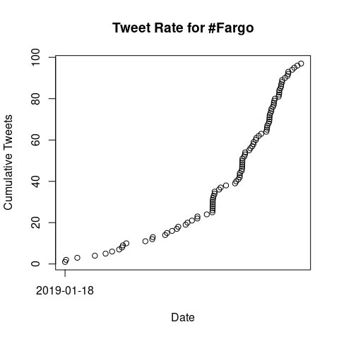

```r
created.at <- sapply(
  statuses,
  function(x) return(
    x$created_at
  )
)

created.at.df <- data.frame(
  created.at = sort(as.POSIXct(created.at,format = "%a %b %d %H:%M:%S +0000 %Y")),
  cumulative.tweets = 1:length(created.at)
)

plot(
  created.at.df$created.at,
  created.at.df$cumulative.tweets,
  main = sprintf(
    "Tweet Rate for %s",
    search.term
  ),
  xlab = "Date",
  ylab = "Cumulative Tweets",
  xaxt = "n"
)
axis.POSIXct(
  1,
  at=seq(
    min(
      created.at.df$created.at
    ),
    max(
      created.at.df$created.at
    ),
    by="day"
  ),
  format = "%Y-%m-%d"
)
```

### Word Cloud

We can also make a word cloud of the status text. Note that this functionality is also provided in this package for Tweets in a standard database format. See the documentation for `twitter_database` and `wordcloud_plot`. The code below does not make use of these functions.

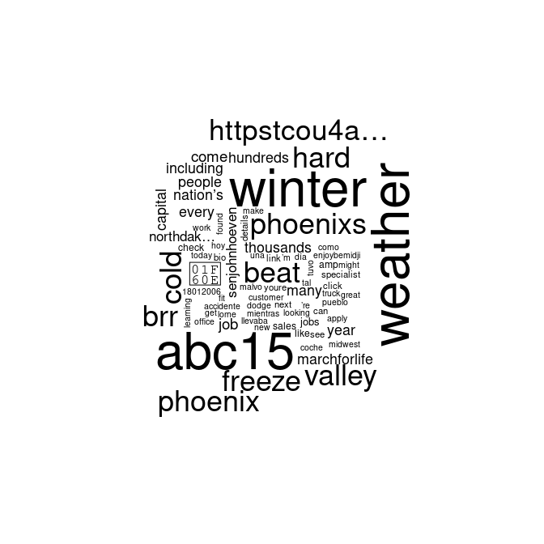

```r
tweet.text <- paste(
  sapply(
    statuses,
    function(x) return(x$full_text)
  ),
  collapse = " "
)
tweet.text <- tolower(tweet.text)

#Remove 'Fargo' because it is in all Tweets
tweet.text <- gsub('fargo','',tweet.text,ignore.case=TRUE)

wordcloud::wordcloud(tweet.text,max.words=100)
```

### Most retweeted statuses

Now let’s see which status has been Retweeted the most. It is important to note that these counts are a static snapshot of retweet counts, while the actual Twitter Retweet counts are always changing as users continue to Retweet.

```r
not.retweets <- which(
  sapply(
    statuses,
    function(x) if("retweeted_status" %in% names(x)) return(FALSE) else return(TRUE)
  )
)

retweet.dataframe <- data.frame(
  user = sapply(
    statuses[not.retweets],
    function(x) return(x$user$screen_name)
  ),
  text = sapply(
    statuses[not.retweets],
    function(x) return(x$full_text)
  ),
  retweet.count = sapply(
    statuses[not.retweets],
    function(x) return(x$retweet_count)
  ),
  stringsAsFactors = FALSE
)


retweet.dataframe <- retweet.dataframe[order(retweet.dataframe$retweet.count,decreasing = TRUE),]

knitr::kable(
  data.frame(
    Screen_Name = paste("@",retweet.dataframe$user[1:5],sep=""),
    Text = gsub("\n"," -- ",retweet.dataframe$text[1:5]),
    Retweet_Count = retweet.dataframe$retweet.count[1:5],
    stringsAsFactors = FALSE
  ),
  caption = "Most Retweeted #Fargo Tweets"
)
```

Most Retweeted #Fargo Tweets

| Screen_Name | Text | Retweet_Count |
| --- | --- | --- |
| @abc15 | Phoenix’s “winter weather” is hard to beat 😎 – #Winter #Brr #Cold #Phoenix #Valley #Fargo #Freeze #Weather #abc15 https://t.co/U4AIDUAtMO | 37 |
| @SenJohnHoeven | Every year, hundreds of thousands of people come to our nation’s capital to #MarchForLife, including many from #NorthDakota. I met w/ students from #Fargo Shanley HS & #Minot’s Bishop Ryan HS to outli… | 12 |
| @Acevedismos | Tal día como hoy, 18/01/2006, Lorne Malvo tuvo un accidente de coche en el pueblo de Bemidji mientras llevaba a una de sus víctimas en el maletero. Después fue al hospital a curarse, conoció a Lester … | 2 |
| @AgCountryHR | It’s not too late to apply to become our next Learning & Development Specialist! Check out the details, here! https://t.co/fzLS4Ez9gb #jobs #Fargo #hiring | 1 |
| @AgCountryHR | #NowHiring: Farm #Accounting Specialist in our #Fargo office. Full details can be found by clicking here: https://t.co/zEegxDybJ2 #agcareers | 1 |

## Analysis of Users

Now we’ll take a look at some basic characteristics of users in the data we’ve collected.

### Unique Users

First, we’ll create a list of unique users.

```r
users <- lapply(
  statuses,
  function(x) return(x$user)
)

user_ids <- sapply(
  users,
  function(x) return(x$id_str)
)

unique.user_id.indices <- which(!duplicated(user_ids))
unique.users <- users[unique.user_id.indices]
```

### Followers counts

Now we can see who in the dataset has the most followers.

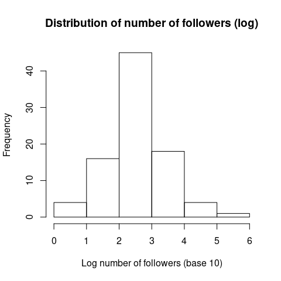

```r
followers.counts <- sapply(
  unique.users,
  function(x) return(x$followers_count)
)

hist(
  log10(followers.counts+1),
  breaks = 0:ceiling(max(log10(followers.counts+1))),
  main = "Distribution of number of followers (log)",
  xlab = "Log number of followers (base 10)"
)
```

### User status counts

Seeing who Tweets the most follows a similar process.

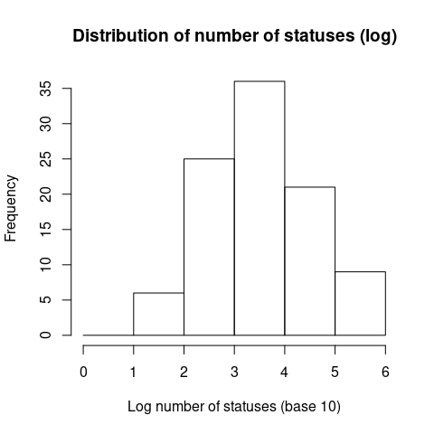

```r
status.counts <- sapply(
  users,
  function(x) return(x$statuses_count)
)

hist(
  log10(status.counts+1),
  breaks = 0:ceiling(max(log10(status.counts+1))),
  main = "Distribution of number of statuses (log)",
  xlab = "Log number of statuses (base 10)"
)
```

### Most prolific #Fargo Tweeters

```r
tweeters <- sapply(
  statuses,
  function(x) return(x$user$screen_name)
)

tweeter.table <- table(tweeters)
names(tweeter.table) <- paste("@",names(tweeter.table),sep="")
tweeter.table <- sort(tweeter.table,decreasing=TRUE)
tweeter.df <- data.frame(
  Screen_Name = names(tweeter.table)[1:5],
  Tweet_Count = as.numeric(tweeter.table[1:5]),
  stringsAsFactors = FALSE
)
knitr::kable(
  tweeter.df,
  caption = "Most prolific #Fargo Tweeters"
)
```

Most prolific #Fargo Tweeters

| Screen_Name | Tweet_Count |
| --- | --- |
| @FargoNDJobs | 4 |
| @tmj_nd_sales | 3 |
| @AgCountry | 2 |
| @AgCountryHR | 2 |
| @perfectdomain1 | 2 |

# Collecting and Analyzing Users and Timelines

This section demonstrates some methods for collecting Users and User Timelines and analyzing the results.

## User search.

Let’s see if we can get some Users from Fargo. We’ll just take the top five of the results.

```r
users <- user_search("Fargo ND")

# Just use up to the first five screen names.

user.screen_names <- sapply(
  users[1:min(c(5,length(users)))],
  function(x) return(x$screen_name)
)

knitr::kable(
  data.frame(
    User = paste("@",user.screen_names,sep="")
  ),
  caption = "Collected Fargo, ND Users"
)
```

Collected Fargo, ND Users

| User |
| --- |
| @FargoNDSchools |
| @bethhooleVNL |
| @AlexEganTV |
| @DowntownFargo |
| @TEDxFargo |

## Collect user timelines

Now we collect these users’ timelines. This will take a few minutes because of the Twitter rate limits. This is the first demonstration of one of the API recursive functions, which inserts a delay in each call to prevent exceeding Twitter rate limits. This function, `user_timeline_recursive`, recursively calls the `user_timeline` function. See the documentation on these functions for details.

```r
user.timelines <- list()
for(i in 1:length(user.screen_names)){
  user.timelines[[user.screen_names[i]]] <- user_timeline_recursive(screen_name = user.screen_names[i])
}
```

## A look at the first user

We’ll look at the first user’s Tweets.

```r
screen.name <- user.screen_names[1]
timeline <- user.timelines[[screen.name]]
```

### Word Cloud

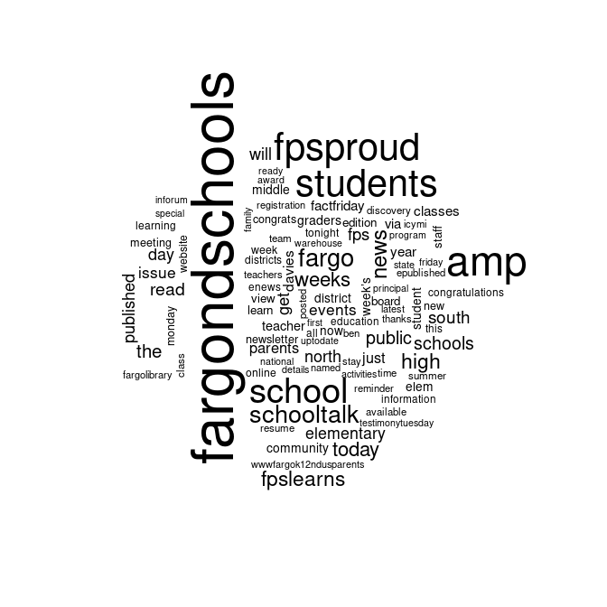

```r
status.text <- paste(
  sapply(
    timeline,
    function(x) return(x$full_text)
  ),
  collapse=" "
)

wordcloud::wordcloud(status.text,max.words = 100)
```

### Most-used hashtags

```r
hashtags <- unlist(
  lapply(
    timeline,
    function(x) {
      lapply(
        x$entities$hashtags,
        function(y) return(y$text)
      )
    }
  )
)

hashtag.table <- sort(table(tolower(hashtags)),decreasing = TRUE)
knitr::kable(
  data.frame(
    Hashtag = paste("#",names(hashtag.table[1:10]),sep=""),
    Count = as.numeric(hashtag.table[1:10]),
    stringsAsFactors = FALSE
  ),
  caption=sprintf("@%s most-used hashtags",screen.name)
)
```

@FargoNDSchools most-used hashtags

| Hashtag | Count |
| --- | --- |
| #fpsproud | 530 |
| #fpslearns | 231 |
| #factfriday | 113 |
| #icymi | 44 |
| #testimonytuesday | 42 |
| #21stcenturyskills | 28 |
| #fargo | 26 |
| #thankyou | 24 |
| #votemarch7 | 22 |
| #ilovefargo | 15 |

### User mentions

```r
usermentions <- unlist(
  lapply(
    timeline,
    function(x) {
      lapply(
        x$entities$user_mentions,
        function(y) return(y$screen_name)
      )
    }
  )
)

usermention.table <- sort(table(tolower(usermentions)),decreasing = TRUE)
knitr::kable(
  data.frame(
    Mentioned_User = paste("@",names(usermention.table[1:10]),sep=""),
    Count = as.numeric(usermention.table[1:10]),
    stringsAsFactors = FALSE
  ),
  caption=sprintf("@%s most-mentioned Users",screen.name)
)
```

@FargoNDSchools most-mentioned Users

| Mentioned_User | Count |
| --- | --- |
| @fargondschools | 876 |
| @fargolibrary | 52 |
| @trollwood | 32 |
| @fargopolice | 24 |
| @cityoffargo | 21 |
| @fpsfoundation | 19 |
| @fpscarlben | 17 |
| @fargodavies | 13 |
| @ndseec | 12 |
| @nddpi | 11 |

## A look at all Users together

Now we’ll combine all of our User’s Tweets and carry out the same analyses.

### Wordcloud

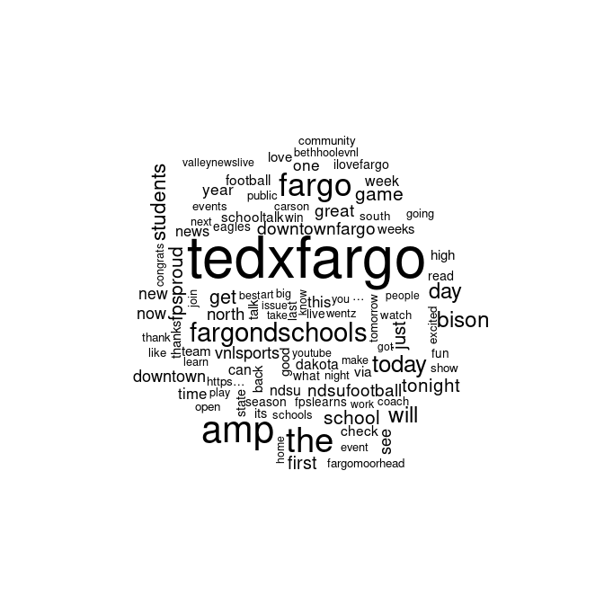

```r
status.text <- paste(
  sapply(user.timelines,
    function(timeline){
      paste(
        sapply(
          timeline,
          function(x) return(x$full_text)
        ),
        collapse=" "
      )
    }
  ),
  collapse = " "
)

wordcloud::wordcloud(status.text,max.words = 100)
```

### Most-used hashtags

```r
hashtags <- unlist(
  lapply(
    user.timelines,
    function(timeline){
      unlist(
        lapply(
          timeline,
          function(x) {
            lapply(
              x$entities$hashtags,
              function(y) return(y$text)
            )
          }
        )
      )
    }
  )
)

hashtag.table <- sort(table(tolower(hashtags)),decreasing = TRUE)
knitr::kable(
  data.frame(
    Hashtag = paste("#",names(hashtag.table[1:10]),sep=""),
    Count = as.numeric(hashtag.table[1:10]),
    stringsAsFactors = FALSE
  ),
  caption="All Users most-used hashtags"
)
```

All Users most-used hashtags

| Hashtag | Count |
| --- | --- |
| #tedxfargo | 927 |
| #fpsproud | 530 |
| #ilovefargo | 251 |
| #fpslearns | 231 |
| #fargo | 208 |
| #factfriday | 113 |
| #downtownfargo | 100 |
| #1mcfar | 65 |
| #probison | 64 |
| #ndsubison | 51 |

### User mentions

```r
usermentions <- unlist(
  lapply(
    user.timelines,
    function(timeline){
      unlist(
        lapply(
          timeline,
          function(x) {
            lapply(
              x$entities$user_mentions,
              function(y) return(y$screen_name)
            )
          }
        )
      )
    }
  )
)

usermention.table <- sort(table(tolower(usermentions)),decreasing = TRUE)
knitr::kable(
  data.frame(
    Mentioned_User = paste("@",names(usermention.table[1:10]),sep=""),
    Count = as.numeric(usermention.table[1:10]),
    stringsAsFactors = FALSE
  ),
  caption="All Users most-mentioned users"
)
```

All Users most-mentioned users

| Mentioned_User | Count |
| --- | --- |
| @fargondschools | 877 |
| @tedxfargo | 862 |
| @ndsufootball | 453 |
| @vnlsports | 420 |
| @downtownfargo | 353 |
| @bethhoolevnl | 200 |
| @fargomoorhead | 179 |
| @valleynewslive | 178 |
| @youtube | 161 |
| @emergingprairie | 140 |